# Лабораторна робота №3

Конько Ярослав, КН-24-1

## Тема

Основи вибіркового методу

## Мета роботи

Засвоїти основи статистичного оцінювання характеристик випадкової величини на засаді вибіркового підходу засобами мови програмування R; набути навичок роботи у середовищі RStudio із застосуванням концепції «грамотного програмування» із застосуванням пакету R Markdown

## Хід роботи

### 1. Постановка завдання з детальним описом заданого розподілу і його параметрів

**Вихідна вибірка:** `[5, 4, 4, 9, 5]`

**Що треба зробити:** Обчислити числові та функціональні характеристики заданої вибірки згідно з методологією вибіркового методу.

### 2. Розв’язок задачі

```r
# Вхідні дані
x <- c(5, 4, 4, 9, 5)

# Основні статистики
cat("Вибірка:", x, "\n")
```

```
Вибірка: 5 4 4 9 5
```

```r
cat("Кількість:", length(x), "\n")
```

```
Кількість: 5
```

```r
cat("Сума:", sum(x), "\n")
```

```
Сума: 27
```

```r
cat("Середнє:", mean(x), "\n")
```

```
Середнє: 5.4
```

```r
cat("Медіана:", median(x), "\n")
```

```
Медіана: 5
```

```r
cat("Мода:", names(sort(table(x), decreasing = TRUE)[1]), "\n")
```

```
Мода: 4
```

```r
# Мінімум і максимум
cat("Мінімум:", min(x), "\n")
```

```
Мінімум: 4
```

```r
cat("Максимум:", max(x), "\n")
```

```
Максимум: 9
```

```r
# Дисперсія і стандартне відхилення
cat("Дисперсія:", var(x), "\n")
```

```
Дисперсія: 4.3
```

```r
cat("Стандартне відхилення:", sd(x), "\n")
```

```
Стандартне відхилення: 2.073644
```

```r
# Квантилі
cat("Квантилі:\n")
```

```
Квантилі:
```

```r
print(quantile(x))
```

```
  0%  25%  50%  75% 100%
   4    4    5    5    9
```

```r
# Таблиця частот
cat("Частоти:\n")
```

```
Частоти:
```

```r
print(table(x))
```

```
x
4 5 9
2 2 1
```

```r
a <- mean(x)
s <- sd(x)

# Створюємо графічне вікно з 4 панелями
op <- par(mfrow = c(2, 2))

# 1. Гістограма з нормальною кривою
hist(x,
     freq = FALSE,
     col = "lightblue",
     main = "Histogram",
     border = 4,
     xlab = "x",
     ylab = "Щільність")

curve(dnorm(x, a, s),
      col = "red",
      lty = 2,
      lwd = 2,
      add = TRUE)
```

```r
# 2. Емпірична функція розподілу
Fn <- ecdf(x)
plot(Fn,
     main = "Quantile Plot",
     verticals = TRUE,
     col.points = "blue",
     col.hor = "red",
     col.vert = "lightblue",
     xlab = "x",
     ylab = "Fn(x)")

# 3. Boxplot з точками
boxplot(x,
        main = "Box-and-Wisker Plot",
        col = "lightyellow",
        border = 4,
        xlab = "x",
        ylab = "Значення",
        horizontal = FALSE)
```

```r
# Додаємо точки
points(rep(1, length(x)), x, pch = 19, col = "red", cex = 1.2)

# 4. Ядерна оцінка щільності
plot(density(x),
     main = "density trace",
     xlab = "x",
     ylab = "Щільність",
     col = "blue",
     lwd = 2)
```

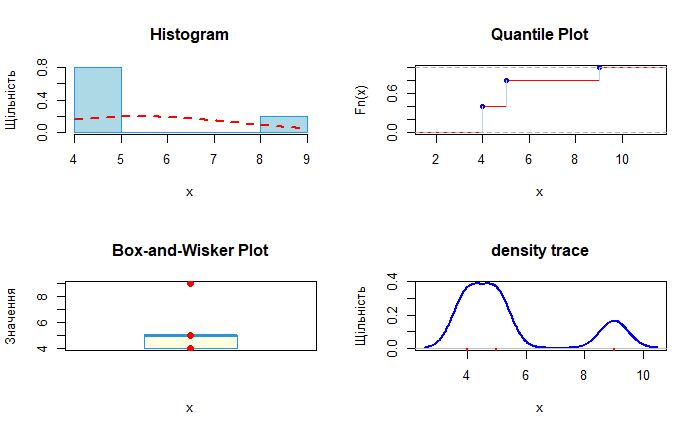

```r
rug(x, col = "red", lwd = 2)

# Повертаємо параметри графіків
par(op)
```

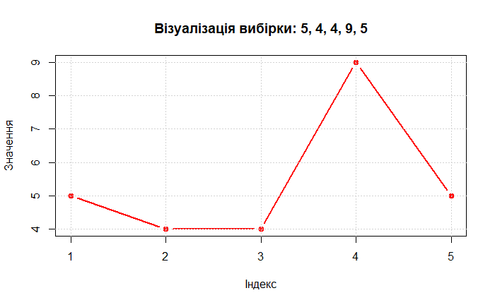

```r
# Простий графік
plot(x,
     type = "b",
     main = "Візуалізація вибірки: 5, 4, 4, 9, 5",
     xlab = "Індекс",
     ylab = "Значення",
     pch = 19,
     col = "red",
     lwd = 2)
grid()
```

### 3. Висновки

#### 2. Мінімум і максимум

- Мінімум: $4$
- Максимум: $9$

#### 3. Міри варіації

- Дисперсія: $s^2 = 4.3$
- Стандртне відхилення: $s = 2.07$
- Коефіцієнт варіації: $CV = 38.4\%$ свідчить про помірну варіабельність даних

## Контрольні питання

### 1. Що таке вибірка?

Вибірка - це обмежена підмножина даних з генеральної сукупності, що використовується для статистичного аналізу.

### 2. Як можна оцінити вибіркове математичне сподівання?

Вибіркове математичне сподівання оцінюється як середнє арифметичне.

### 3. Які існують міри розсіювання?

Міри розсіювання:

- Дисперсія (var())
- Стандартне відхилення (sd())
- Розмах (range())
- Міжквартильний розмах (IQR())

### 4. Які міри форми розподілу вам відомі? Що вони характеризують? Як їх оцінити на практиці?

Міри форми розподілу:

- Асиметрія (skewness()) - характеризує симетрію розподілу
- Ексцес (kurtosis()) - характеризує крутість розподілу

На практиці оцінюють: за допомогою функцій з пакету moments. Асиметрія ≈ 0 - симетричний розподіл, ексцес ≈ 0 - нормальна крутість.

## Перелік посилань:

Сидоренко, В. М. 2023. *Ймовірнісно-Статистичні Методи Інформаційних Технологій*. Кременчуцький національний університет.